# Poisson Regression for Cyclist Counts and Rates on the Manhattan Bridge

Hayden Patterson

11-01-2026

# 1 Data Description

The daily total of bike counts was conducted monthly on the Brooklyn Bridge, Manhattan Bridge, Williamsburg Bridge, and Queensboro Bridge. To keep count of cyclists entering and leaving Queens, Manhattan, and Brooklyn via the East River Bridges. The Traffic Information Management System (TIMS) collects the count data. Each record represents the total number of cyclists per 24 hours at Brooklyn Bridge, Manhattan Bridge, Williamsburg Bridge, and Queensboro Bridge.

The subset used in this report covers **July 2017** (31 consecutive days) and combines the daily bike counts with daily weather information (temperature and precipitation).

```r
if (!require("readxl")) {
   install.packages("readxl")
   library(readxl)
}

file <- "BikeDataSet.xlsx"
if (!file.exists(file)) {
  download.file("https://raw.githubusercontent.com/88haypa-collab/STA321_f26/main/PoissonRegression/BikeDataSet.xlsx",
                destfile = file, mode = "wb")
}

excel_sheets(file)                      # check how many sheets there are
```

```
 [1] "data1"  "data2"  "data3"  "data4"  "data5"  "data6"  "data7"  "data8"
 [9] "data9"  "data10"
```

```r
bike <- read_excel(file, sheet = 5)     # change the sheet if needed
str(bike)
```

```
tibble [31 × 7] (S3: tbl_df/tbl/data.frame)
 $ Date           : POSIXct[1:31], format: "2017-07-01" "2017-07-02" ...
 $ Day            : POSIXct[1:31], format: "2017-07-01" "2017-07-02" ...
 $ HighTemp       : num [1:31] 84.9 87.1 87.1 82.9 84.9 75 79 82.9 81 82.9 ...
 $ LowTemp        : num [1:31] 72 73 71.1 70 71.1 71.1 68 70 69.1 71.1 ...
 $ Precipitation  : num [1:31] 0.23 0 0.45 0 0 0 1.78 0 0 0 ...
 $ ManhattanBridge: num [1:31] 2958 3776 4199 4084 6770 ...
 $ Total          : num [1:31] 11867 13995 16067 13925 23110 ...
```

```r
kable(head(bike), caption = "First few records in the data set")
```

First few records in the data set

| Date | Day | HighTemp | LowTemp | Precipitation | ManhattanBridge | Total |
| --- | --- | --- | --- | --- | --- | --- |
| 2017-07-01 | 2017-07-01 | 84.9 | 72.0 | 0.23 | 2958 | 11867 |
| 2017-07-02 | 2017-07-02 | 87.1 | 73.0 | 0.00 | 3776 | 13995 |
| 2017-07-03 | 2017-07-03 | 87.1 | 71.1 | 0.45 | 4199 | 16067 |
| 2017-07-04 | 2017-07-04 | 82.9 | 70.0 | 0.00 | 4084 | 13925 |
| 2017-07-05 | 2017-07-05 | 84.9 | 71.1 | 0.00 | 6770 | 23110 |
| 2017-07-06 | 2017-07-06 | 75.0 | 71.1 | 0.00 | 6243 | 21861 |

The data set has 31 rows, one for each day of July 2017. The structure output shows a date column (`Date`), a duplicate date column (`Day`), and five numeric variables. The first few records already show how much the daily counts vary: the Manhattan Bridge count ranges from about 3,000 to 6,800 over the first six days, while the temperature stays in a fairly narrow range.

## 1.1 Variable Definitions

| Variable | Type | Definition |
| --- | --- | --- |
| **Date** | Date (ID) | Calendar date of the observation. It identifies each record and is not used as a predictor. |
| **Day** | Date | Repeats `Date`, so it is not used in the analysis. |
| **HighTemp** | Numeric (°F) | Daily high temperature. |
| **LowTemp** | Numeric (°F) | Daily low temperature. |
| **Precipitation** | Numeric (inches) | Total precipitation for the day. |
| **ManhattanBridge** | Count | Number of cyclists crossing the Manhattan Bridge in 24 hours. This is the response variable. |
| **Total** | Count | Number of cyclists crossing all four East River bridges in 24 hours. It serves as the exposure (offset) in the rate model. |

## 1.2 Summary Statistics

```r
nrow(bike)
```

```
[1] 31
```

```r
cor(bike$HighTemp, bike$LowTemp)
```

```
[1] 0.8136051
```

```r
mean(bike$ManhattanBridge)
```

```
[1] 5424.613
```

```r
var(bike$ManhattanBridge)
```

```
[1] 2453414
```

The output shows 31 observations. The mean daily count on the Manhattan Bridge is about 5,425, but the variance is about 2,453,414, roughly 450 times larger. A Poisson variable has a mean equal to its variance, so this is an early warning of **overdispersion**. Part of the spread comes from the mean changing with the weather, so we judge the problem more fairly after fitting the model.

`HighTemp` and `LowTemp` have a correlation of about 0.81. Because the two measure much of the same thing, putting both in a model can make one of them look insignificant even if temperature matters. We keep this in mind during variable selection.

Finally, the observations are consecutive days in a single month, so they may not be fully independent (a rainy day can affect the next day’s ridership), and with only 31 records, the tests have limited power.

## 1.3 Distribution of the Response Variable

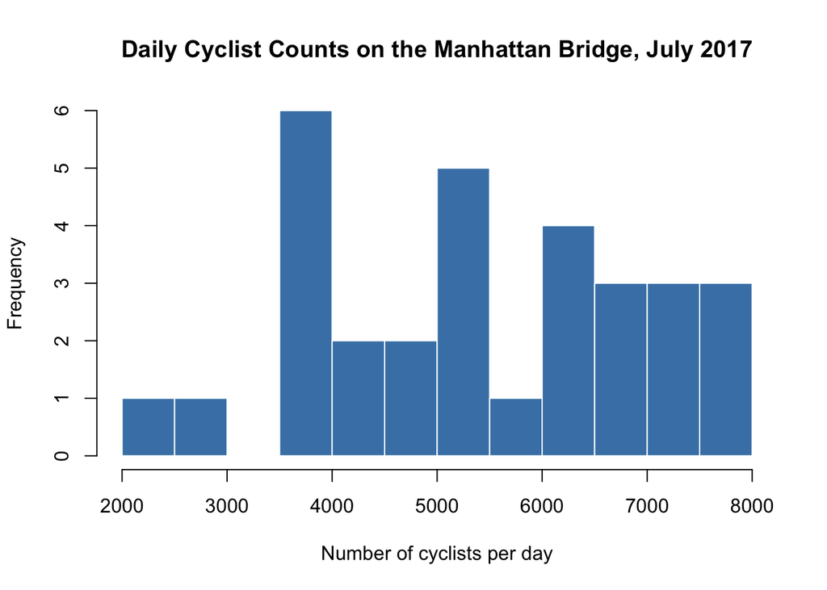

```r
hist(bike$ManhattanBridge, breaks = 10, col = "#4682B4", border = "white",
     main = "Daily Cyclist Counts on the Manhattan Bridge, July 2017",
     xlab = "Number of cyclists per day")
```

The histogram shows how the daily Manhattan Bridge counts are spread out. The histogram has a uneaven spread, there is a wide range from 2000 to 8000 with more aboce 5000 per day. This wide spread matches the variance of about 2,453,414 that we found earlier, which is far larger than the mean of about 5,425. It supports the earlier warning about overdispersion, and we keep it in mind when judging the Poisson model.

# 2 Research Questions

The goal of this analysis is to understand how daily weather conditions are associated with cyclist traffic on the Manhattan Bridge in July 2017. We focus on two specific questions.

1. **Counts:** Are the daily high temperature, daily low temperature, and precipitation associated with the number of cyclists who cross the Manhattan Bridge in a day?
2. **Rates:** Are these weather variables associated with the Manhattan Bridge’s *share* of all cyclists crossing the four East River bridges? That is, does weather change how many cyclists choose the Manhattan Bridge relative to the other three bridges, after accounting for total traffic?

The response variable for the first question is the daily count `ManhattanBridge`. For the second question, the response is still `ManhattanBridge`, but the model uses `Total` (the daily count across all four bridges) as the exposure, so the model describes the rate $\text{ManhattanBridge}/\text{Total}$.

# 3 Model Description and Assumptions

Because the response is a count of events (cyclists) in a fixed period (24 hours), we use Poisson regression. Let $Y$ be the daily Manhattan Bridge count and $\mu = E[Y]$.

**Poisson model for counts:**

$$\log(\mu) = \beta_0 + \beta_1 \text{HighTemp} + \beta_2 \text{LowTemp} +
\beta_3 \text{Precipitation}$$

Here $e^{\beta_i}$ is the multiplicative change in the expected daily count for a one-unit increase in the predictor, with the other predictors held fixed.

**Poisson model for rates:**

$$\log(\mu/\text{Total}) = \beta_0 + \beta_1 \text{HighTemp} + \beta_2
\text{LowTemp} + \beta_3 \text{Precipitation}$$

which can be written as

$$\log(\mu) = \beta_0 + \beta_1 \text{HighTemp} + \beta_2 \text{LowTemp} +
\beta_3 \text{Precipitation} + \log(\text{Total}),$$

where $\log(\text{Total})$ is an offset with its coefficient fixed at 1. Here $e^{\beta_i}$ is the multiplicative change in the Manhattan Bridge’s share of total bridge traffic.

**Assumptions:**

- **Poisson response:** the response is a non-negative integer count.
- **Independence:** observations are independent. Our data are consecutive days, so weather or events on one day may affect the next, and this assumption may be only approximately met.
- **Mean equals variance:** the Poisson distribution requires equidispersion. The sample mean (about 5,425) is far below the sample variance (about 2,453,414), which suggests overdispersion. We will examine this in the diagnostics next week, and remedies such as quasi-Poisson or negative binomial regression may be needed. Until then, the p-values from the Poisson fit should be read with caution, since overdispersion makes standard errors too small.
- **Linearity:** $\log(\mu)$ is a linear function of the predictors.

**Variable selection:** in both models we start with all three weather variables and remove the least significant one at a time (using the Wald p-values), refitting after each removal until all remaining variables are significant at the 0.05 level.

# 4 Poisson Regression on Counts

We first build a Poisson regression model for the daily number of cyclists on the Manhattan Bridge and ignore the total traffic across the four bridges. We start with all three weather variables as candidate predictors.

## 4.1 Full Model and Variable Selection

```r
model.full <- glm(ManhattanBridge ~ HighTemp + LowTemp + Precipitation,
                  family = poisson(link = "log"), data = bike)
count.coef <- summary(model.full)$coef
kable(count.coef, caption = "Poisson regression model for the daily Manhattan Bridge counts versus
      high temperature, low temperature, and precipitation.")
```

Poisson regression model for the daily Manhattan Bridge counts versus high temperature, low temperature, and precipitation.

|  | Estimate | Std. Error | z value | Pr(>\|z\|) |
| --- | --- | --- | --- | --- |
| (Intercept) | 8.4223984 | 0.0413062 | 203.901464 | 0 |
| HighTemp | 0.0086072 | 0.0006714 | 12.819677 | 0 |
| LowTemp | -0.0067923 | 0.0009425 | -7.206675 | 0 |
| Precipitation | -0.4914197 | 0.0094934 | -51.764290 | 0 |

The inferential table shows that all three predictors have p-values far below 0.05. `HighTemp` and `LowTemp` have z-values of about 12.8 and -7.2, and `Precipitation` has a z-value of about -51.8. Because every variable is significant, the selection procedure has nothing to remove: no variable is dropped, and the full model is the final count model.

## 4.2 Interpretation of the Coefficients

In a Poisson regression with a log link, each coefficient is a change in the log of the expected count, so $e^{\beta}$ is the multiplicative change in the expected daily count for a one-unit increase in the predictor, with the other predictors fixed.

```r
kable(round(exp(coef(model.full)), 4),
      caption = "exp(beta): multiplicative effect on the expected daily count")
```

exp(beta): multiplicative effect on the expected daily count

|  | x |
| --- | --- |
| (Intercept) | 4547.7979 |
| HighTemp | 1.0086 |
| LowTemp | 0.9932 |
| Precipitation | 0.6118 |

- **Precipitation** ($\hat\beta = -0.4914$, $e^{\hat\beta} \approx 0.612$). Each additional inch of precipitation reduces the expected daily count by about 38.8%, holding the temperatures fixed. An inch of rain in a day is large, so a more practical scale is 0.1 inch: $e^{-0.0491} \approx 0.952$, or about 5% fewer cyclists. This is the strongest effect in the model, and it makes sense because riders avoid wet, slippery bridge crossings.
- **HighTemp** ($\hat\beta = 0.0086$, $e^{\hat\beta} \approx 1.009$). Each additional degree Fahrenheit in the daily high raises the expected count by about 0.86%, with the low temperature and precipitation fixed.
- **LowTemp** ($\hat\beta = -0.0068$, $e^{\hat\beta} \approx 0.993$). Each additional degree in the daily low lowers the expected count by about 0.68%, with the high temperature and precipitation fixed.

The negative sign on `LowTemp` does not mean that warmer nights discourage cycling. `HighTemp` and `LowTemp` have a correlation of about 0.81, so each coefficient describes the effect of one temperature *while the other is held fixed*, which is a rare situation in real weather. A better reading is the combined effect. If both temperatures rise by one degree, the log count changes by $0.0086 - 0.0068 \approx 0.0018$, an increase of only about 0.18%. In July it is warm enough to ride either way, so temperature has a very small overall effect, and precipitation is what moves ridership.

## 4.3 Goodness of Fit

```r
disp.ratio <- model.full$deviance / model.full$df.residual
cat("Residual deviance:", round(model.full$deviance, 1),
    "on", model.full$df.residual, "degrees of freedom\n")
```

```
Residual deviance: 10349.9 on 27 degrees of freedom
```

```r
cat("Deviance / df:", round(disp.ratio, 1), "\n")
```

```
Deviance / df: 383.3
```

The residual deviance is about 10,350 on 27 degrees of freedom, a ratio of about 383. For a Poisson model that fits well, this ratio should be near 1. This confirms the overdispersion we saw earlier in the mean (about 5,425) and variance (about 2,453,414). As a result, the standard errors in the table above are too small, and the p-values are smaller than they should be. The direction and rough size of the effects are still a reasonable description of the data, but the strength of the evidence is overstated. Next week’s diagnostics will look at quasi-Poisson and negative binomial models, which give more honest inference.

## 4.4 Summary of the Count Model

- All three weather variables are statistically significant in the Poisson fit, so none was removed.
- Rain strongly reduces ridership: about 5% fewer cyclists per 0.1 inch.
- The individual temperature effects are small and opposite in sign because of the correlation between the high and the low, and the combined effect is close to zero.
- The p-values are overstated because of overdispersion, so these conclusions should be treated with caution.

# 5 Poisson Regression on Rates

The count model ignores how many cyclists used the East River bridges overall on each day. On a rainy day, fewer people ride on every bridge, so a drop on the Manhattan Bridge may only reflect a drop in total traffic. To separate the two, we model the Manhattan Bridge’s *rate* (its share of total traffic) by adding $\log(\text{Total})$ as an offset.

## 5.1 Full Model and Variable Selection

```r
model.rate <- glm(ManhattanBridge ~ HighTemp + LowTemp + Precipitation,
                  offset = log(Total), family = poisson(link = "log"), data = bike)
kable(summary(model.rate)$coef, caption = "Full Poisson rate model: Manhattan Bridge
      share of total traffic versus high temperature, low temperature, and precipitation.")
```

Full Poisson rate model: Manhattan Bridge share of total traffic versus high temperature, low temperature, and precipitation.

|  | Estimate | Std. Error | z value | Pr(>\|z\|) |
| --- | --- | --- | --- | --- |
| (Intercept) | -1.1446512 | 0.0408894 | -27.9938137 | 0.0000000 |
| HighTemp | -0.0002162 | 0.0006761 | -0.3198215 | 0.7491036 |
| LowTemp | -0.0010643 | 0.0009325 | -1.1412692 | 0.2537579 |
| Precipitation | -0.0522667 | 0.0085488 | -6.1139323 | 0.0000000 |

In the full model only `Precipitation` is significant (p < 0.001). `HighTemp` has p = 0.749 and `LowTemp` has p = 0.254. We remove the least significant variable, `HighTemp`, and refit.

```r
model.rate2 <- glm(ManhattanBridge ~ LowTemp + Precipitation,
                   offset = log(Total), family = poisson(link = "log"), data = bike)
kable(summary(model.rate2)$coef, caption = "Poisson rate model after removing HighTemp.")
```

Poisson rate model after removing HighTemp.

|  | Estimate | Std. Error | z value | Pr(>\|z\|) |
| --- | --- | --- | --- | --- |
| (Intercept) | -1.1457923 | 0.0407346 | -28.128216 | 0.0000000 |
| LowTemp | -0.0013005 | 0.0005690 | -2.285599 | 0.0222777 |
| Precipitation | -0.0520832 | 0.0085290 | -6.106580 | 0.0000000 |

After `HighTemp` is removed, `LowTemp` becomes significant (p = 0.022). This is a collinearity effect. The high and low temperatures have a correlation of about 0.81, so in the full model they shared the same information and each looked unimportant. With only one temperature left, it picks up the signal. Both remaining variables have p-values below 0.05, so the selection stops, and the final rate model contains `LowTemp` and `Precipitation`.

## 5.2 Interpretation of the Coefficients

```r
kable(round(exp(coef(model.rate2)), 4),
      caption = "exp(beta): multiplicative effect on the Manhattan Bridge share of total traffic")
```

exp(beta): multiplicative effect on the Manhattan Bridge share of total traffic

|  | x |
| --- | --- |
| (Intercept) | 0.3180 |
| LowTemp | 0.9987 |
| Precipitation | 0.9492 |

- **Precipitation** ($\hat\beta = -0.0521$, $e^{\hat\beta} \approx 0.949$). Each additional inch of precipitation lowers the Manhattan Bridge’s share of total bridge traffic by about 5.1%, holding the low temperature fixed. For 0.1 inch, the share falls by about 0.5%.
- **LowTemp** ($\hat\beta = -0.0013$, $e^{\hat\beta} \approx 0.9987$). Each additional degree in the daily low lowers the share by about 0.13%, holding precipitation fixed. A 10°F rise lowers it by about 1.3%. This is a very small effect, and the data cannot tell us why it occurs.

The `LowTemp` result is only modest evidence. It is significant at the 0.05 level, only appears after a correlated variable is removed, and rests on 31 days.

## 5.3 Robustness Check

```r
model.rate3 <- glm(ManhattanBridge ~ Precipitation,
                   offset = log(Total), family = poisson(link = "log"), data = bike)
kable(summary(model.rate3)$coef, caption = "Rate model with Precipitation only (comparison).")
```

Rate model with Precipitation only (comparison).

|  | Estimate | Std. Error | z value | Pr(>\|z\|) |
| --- | --- | --- | --- | --- |
| (Intercept) | -1.2387284 | 0.0025488 | -486.012513 | 0 |
| Precipitation | -0.0494116 | 0.0084490 | -5.848249 | 0 |

```r
exp(coef(model.rate3))
```

```
  (Intercept) Precipitation
    0.2897524     0.9517892
```

As a check, we refit the model with precipitation alone. The coefficient is -0.0494 ($e^{\hat\beta} \approx 0.952$), almost the same as in the final model, so the rain effect does not depend on whether `LowTemp` is included. The intercept gives $e^{-1.2387} \approx 0.29$, so on a dry day the Manhattan Bridge carries about 29% of all East River bridge cyclists in this data.

## 5.4 Goodness of Fit

```r
cat("Final rate model deviance / df:",
    round(model.rate2$deviance / model.rate2$df.residual, 1), "\n")
```

```
Final rate model deviance / df: 14.1
```

# 6 Summary of Findings

```r
comp <- data.frame(
  Predictor = c("HighTemp", "LowTemp", "Precipitation"),
  Count_Model = c("Significant (+0.86% per °F)", "Significant (-0.68% per °F)", "Significant (-38.8% per inch)"),
  Rate_Model  = c("Removed (p = 0.749)", "Significant (-0.13% per °F)", "Significant (-5.1% per inch)")
)
kable(comp, caption = "Comparison of the final count and rate models")
```

Comparison of the final count and rate models

| Predictor | Count_Model | Rate_Model |
| --- | --- | --- |
| HighTemp | Significant (+0.86% per °F) | Removed (p = 0.749) |
| LowTemp | Significant (-0.68% per °F) | Significant (-0.13% per °F) |
| Precipitation | Significant (-38.8% per inch) | Significant (-5.1% per inch) |

1. **Rain is the dominant weather effect.** It is the only variable that is clearly significant in both models. Each inch of precipitation is associated with about 39% fewer cyclists on the Manhattan Bridge (about 5% per 0.1 inch), which fits the idea that riders avoid wet, slippery crossings.
2. **Most of the rain effect is shared across all four bridges.** In the rate model the effect shrinks to about 5% per inch. Most of the drop in Manhattan Bridge counts is therefore explained by fewer people riding everywhere, and only a small extra drop is specific to this bridge.
3. **Temperature matters very little.** In the count model, the high and low temperatures have opposite signs and nearly cancel (combined effect about +0.18% per degree), because they are highly correlated and July is warm enough to ride either way. In the rate model, `HighTemp` is removed and `LowTemp` has a tiny effect on the bridge’s share.
4. **Weather strongly changes how many people ride, but only slightly changes which bridge they choose.**

# 7 Concluding Remarks

This report used Poisson regression to study how weather relates to daily cyclist traffic on the Manhattan Bridge in July 2017. Modeling the raw counts shows how much weather moves ridership, and modeling the rate, with total bridge traffic as the offset, shows whether weather changes the Manhattan Bridge’s share. Comparing the two models separated the effect of weather on overall ridership from its effect on bridge choice. Precipitation lowers ridership on all four bridges and only slightly shifts riders away from the Manhattan Bridge. Temperature has little effect in July.

In practice, a transportation planner could expect much lower Manhattan Bridge volume on rainy days. The drop mostly reflects fewer riders citywide, not a shift to other bridges.

The Poisson assumption that the variance equals the mean is clearly violated here, especially in the count model, so the p-values are too small and the evidence is overstated. The next step is a model diagnostic. Quasi-Poisson or negative binomial regression would give more reliable standard errors, and adding a weekday or weekend indicator could capture commuting patterns that these weather variables miss.